# EP02-respuesta-equipo-6

Autores: Martín Alvayay y Sofia Rojas

Cargando librerías

```r
suppressPackageStartupMessages(library("dplyr"))
suppressPackageStartupMessages(library("DT"))
suppressPackageStartupMessages(library("ggpubr"))
```

Cargando datos

```r
datos = read.csv2("EP02 Datos.csv")
```

Análisis de tipos de datos.

```r
str(datos)
```

```
## 'data.frame':    81 obs. of  4 variables:
##  $ Id       : int  1 2 3 4 5 6 7 8 9 10 ...
##  $ Zona     : chr  "Centro-Sur" "Centro-Sur" "Centro-Norte" "Centro-Sur" ...
##  $ Previo   : num  19.9 21.4 17.2 18.2 12.9 ...
##  $ Posterior: num  15.2 16.3 14 13.1 11.5 ...
```

```r
Nombre_Variables = names(datos) # Nombre de los componentes

Descripcion = c("Identificador único para cada atleta","Zona del club deportivo o establecimiento educacional donde cada atleta fue formado.","Mejor tiempo registrado por el atleta antes de ingresar al programa de entrenamiento.","Mejor tiempo registrado por el atleta después de los primeros 6 meses del programa de entrenamiento")
#Descripción de cada componente

Tipos_variables = c("Numerica discreta","Categorico Nominal","Numerico Continuo","Numerico Continuo")

#Tipos de variables correspondientes a los componentes
#Tabla recopilando los datos anteriores
Tabla_variables = data.frame(Nombre_Variables,Descripcion,Tipos_variables)
datatable(Tabla_variables,
          options = list(pageLength = 4),
          caption = "Tabla de descripción de variables")
```

|  | Nombre_Variables | Descripcion | Tipos_variables |
| --- | --- | --- | --- |
| 1 | Id | Identificador único para cada atleta | Numerica discreta |
| 2 | Zona | Zona del club deportivo o establecimiento educacional donde cada atleta fue formado. | Categorico Nominal |
| 3 | Previo | Mejor tiempo registrado por el atleta antes de ingresar al programa de entrenamiento. | Numerico Continuo |
| 4 | Posterior | Mejor tiempo registrado por el atleta después de los primeros 6 meses del programa de entrenamiento | Numerico Continuo |

### Equipo 6:

### 1. El Comité Olímpico cree que el mejor tiempo medio de los atletas de la zona Centro-Norte antes de ingresar al programa de entrenamiento era 16,2 segundos. ¿Soportan los datos esta afirmación?

Primero para trabajar con los datos, debemos filtrar los datos respecto a la zona de los deportistas, se filtran lo datos para conservar en una tabla solo aquellos de la zona Centro-Norte.

```r
#Se filtran los datos para la variable Zona con valor "Centro-Norte"
data_CN = filter(datos, Zona=="Centro-Norte")
```

### Hipotesis

Una vez filtrados los datos, formulamos las hipotesis

El valor nulo sera 16,2 que es la media poblacional que se quiere confirmar con la muestra.

Entonces nuestras hipotesis serán:

$H_{0}$: El promedio de el mejor tiempo de los atletas de la zona Centro-Norte antes de ingresar al programa es 16,2.
$$H_{0}: \mu = 16,2$$

$H_{A}$: El promedio de el mejor tiempo de los atletas de la zona Centro-Norte es distinto a 16,2.
$$H_{A}: \mu\ne16,2$$
### Prueba Ya teniendo armadas las hipótesis, elegimos una prueba respecto a los que se sabe de la muestra, en este caso:

- La muestra tiene 26 observaciones ($n=26$).
- No se conoce la varianza de la población o si la varianza de la muestra se acerca a la de la población.
- Solo se utiliza una muestra.

Con las dos primeras caracteristicas, se descarta una prueba Z al no cumplir las condiciones por el tamaño de la muestra y la varianza, por lo que se elige una prueba bilateral t de Student para una muestra, sera una prueba bilateral por la hipótesis alternativa, que niega la igualdad.

### Condiciones

Antes de utilizar la prueba, se confirma que se cumplan todas las condiciones:

1. Las observaciones son independientes entre si.
2. La observaciones provienen de una distribución cercana a la normal.

La primera condición se cumple, las observaciones son de distintos atletas, por lo que, son independientes entre si.

Para la segunda condición, se realiza una gráfico Q-Q respecto a la variable “Previo” ( Mejor tiempo registrado por el atleta antes de ingresar al programa de entrenamiento) para observar si los datos trabajan bajo una distribución parecida a la normal.

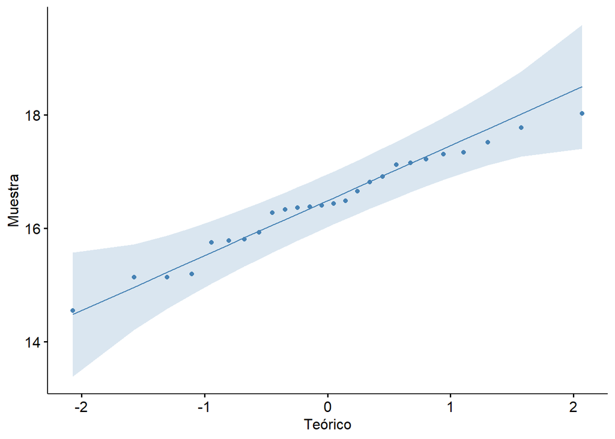

```r
#Se construye grafico Q-Q a partir de los datos filtrados, utilizando los datos de la variable Previo
qq_q1 = ggqqplot(data_CN, x = "Previo", xlab= "Teórico", ylab = "Muestra", alpha = 0.05, color = "steelblue" )
print(qq_q1)
```

Dentro del gráfico, se aprecia que las observaciones de la variable Previo se encuentran dentro del margen de desviación aceptable para suponer que siguen una distribución cercana a la normal.

Corroboramos esto con una prueba de Shapiro-Wilk

```r
shapiro.test(data_CN$Previo)
```

```
##
##  Shapiro-Wilk normality test
##
## data:  data_CN$Previo
## W = 0.97651, p-value = 0.7925
```

El valor p dado por el test es mayor a $\alpha = 0,05$ por lo que no se rechaza que la muestra siga una distribución normal, por lo que se cumple la segunda condición para el test.

### Resultados

Se aplica el test para la muestra para analizar los resultados, con un valor nulo de 16.2 y alpha 0.05

```r
alpha = 0.05
null_value1 = 16.2
t.test(data_CN$Previo, alternative = "two.sided", mu = null_value1, conf.level = 1-alpha)
```

```
##
##  One Sample t-test
##
## data:  data_CN$Previo
## t = 1.4769, df = 25, p-value = 0.1522
## alternative hypothesis: true mean is not equal to 16.2
## 95 percent confidence interval:
##  16.09988 16.80773
## sample estimates:
## mean of x
##  16.45381
```

El valor p dado por el test es mayor al alpha seleccionado, ademas, se tiene un intervalor de confianza de 95% en el intervalo [16,10-16,81] aproximadamente.

### Conclusiones

Segun los datos entregados por la prueba T, no hay suficiente evidencia en la muestra dada como para descartar la hipotesis nula de que la media del mejor tiempo de los atletas de la zona Centro-Norte antes de entrar al programa de entrenamiento sea 16,2 , pues dentro de los resultados del test se dio un intervalo de confianza [16,10-16,81] en donde se puede encontrar nuestro valor nulo dado.

###2. ¿Sugieren los datos que la mejor marca de los atletas de la zona Centro-Sur se reduce en promedio 4,7 segundos tras el entrenamiento?

Para responder esta pregunta, tenemos que identificar las variables a analizar, en este caso la pregunta indica sobre: - Atletas de la zona Centro-Sur - De los tiempos posteriores al entrenamiento en pos del tiempo previo al entrenamiento.

Sobre el contexto, se asume una diferencia positiva del tiempo promedio de los atletas, con x_1 como el tiempo promedio anterior al entrenamiento y x_2 como el tiempo promedio posterior al entrenamiento, por lo que se espera que la mejoría fuera de 4,7 segundos, mientras que por otra parte queremos averiguar si ese cambio, es diferente de 4,7 segundos.
$$H_0: (\bar x_1 - \bar x_2) = 4,7
\\ H_A: (\bar x_1 - \bar x_2) \neq 4,7$$

El estimador puntual, es la diferencia entre los promedios muestrales de antes y después en la muestra de datos, mientras que el valor nulo es 4,7.

Por lo que primero, es filtrar los datos por los atletas pertenecientes a la Zona “Centro-Sur”.

```r
atletas = datos %>% filter(Zona=="Centro-Sur")
dif_atletas = atletas$Previo - atletas$Posterior
```

Definir una prueba de contraste de hipótesis, en este caso se presenta una prueba de contraste de hipótesis de promedio entre muestras pareadas, ya que los tiempos previo y posterior son datos que pertenecen a un mismo sujeto.

```r
length(dif_atletas)
```

```
## [1] 27
```

Dado que el tamaño de la muestra es menor a 30 y se desconoce la desviación poblacional, se tomara una prueba de T de Student, sin antes verificar normalidad en las muestras y independencia de los datos dentro de su propia muestra.

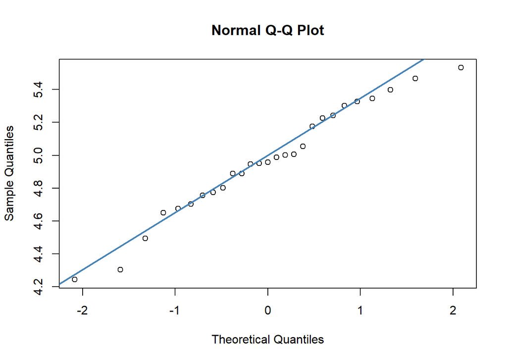

```r
qqnorm(dif_atletas)
qqline(dif_atletas, col = "steelblue", lwd = 2)
```

```r
shapiro.test(dif_atletas)
```

```
##
##  Shapiro-Wilk normality test
##
## data:  dif_atletas
## W = 0.97305, p-value = 0.6839
```

Dado que el tests de hipótesis, normalidad Shapiro-Wilk indican que no hay suficiente evidencia estadística para demostrar que las muestras NO provienen de una distribución normal (p-value > 0.05) y en el QQplot se observa que los datos aproximadamente se alinean a la recta. Por lo que se dice que los datos siguen una distribución normal.

Dado que las condiciones para un test de hipótesis T de Student se cumplen, se realiza el T test pareado de 2 muestras.

```r
t.test(dif_atletas,mu=4.7)
```

```
##
##  One Sample t-test
##
## data:  dif_atletas
## t = 4.1419, df = 26, p-value = 0.0003227
## alternative hypothesis: true mean is not equal to 4.7
## 95 percent confidence interval:
##  4.834232 5.098731
## sample estimates:
## mean of x
##  4.966481
```

### 3. ¿Es posible afirmar que, en promedio, los atletas de la zona Sur superan a los de la zona Centro-Norte por menos de 1 segundo después del entrenamiento?

Para responder esta pregunta, tenemos que identificar las variables a analizar, en este caso la pregunta indica sobre: - Atletas de la zona Sur. - Atletas de la zona Centro-Norte - Mejores tiempos de cada atleta posterior al entrenamiento.

El estimador puntual, es la diferencia entre los promedios muestrales de “después” correspondientes a Centro-Norte y Sur en la muestra de datos.

Por lo que primero, es filtrar los datos por los atletas pertenecientes a la Zona “Sur” y “Centro-Norte”, con sus tiempos posteriores.

```r
Sur_pos = datos %>% filter(Zona == "Sur") %>% select(Posterior)
Cenor_pos = datos %>% filter(Zona == "Centro-Norte") %>% select(Posterior)
```

Definir una prueba de contraste de hipotesis, en este caso se presenta una prueba de contraste de hipótesis de promedio entre muestras no pareadas, ya que los tiempos posterior son en base a diferentes sujetos.

```r
length(Sur_pos$Posterior)
```

```
## [1] 28
```

```r
length(Cenor_pos$Posterior)
```

```
## [1] 26
```

Dado que el tamaño de la muestra es menor a 30 y se desconoce la desviación poblacional, se tomará una prueba de T de Student, sin antes verificar normalidad en las muestras e independencia de los datos dentro de su propia muestra.

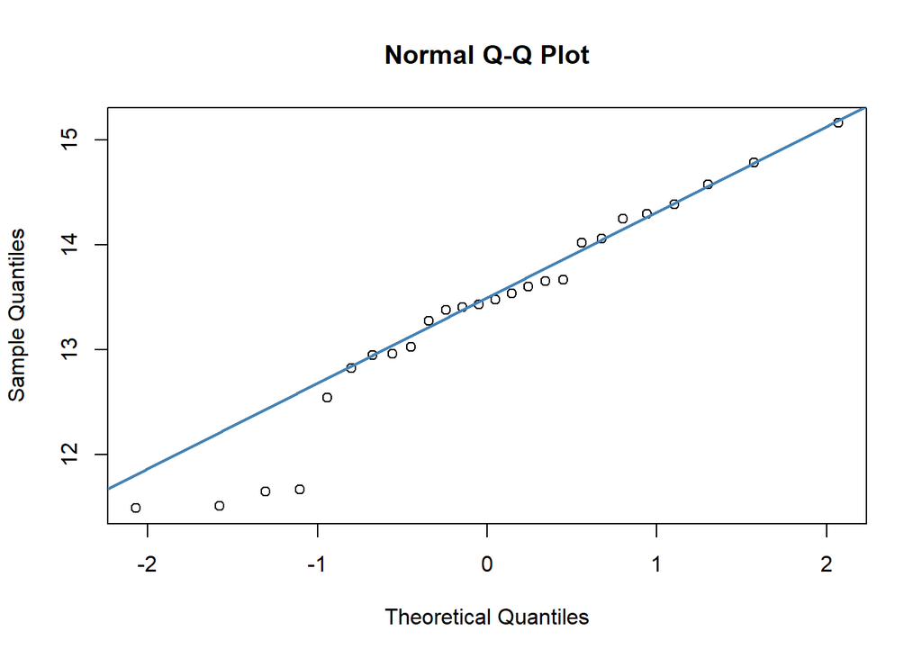

```r
qqnorm(Cenor_pos$Posterior)
qqline(Cenor_pos$Posterior, col = "steelblue", lwd = 2)
```

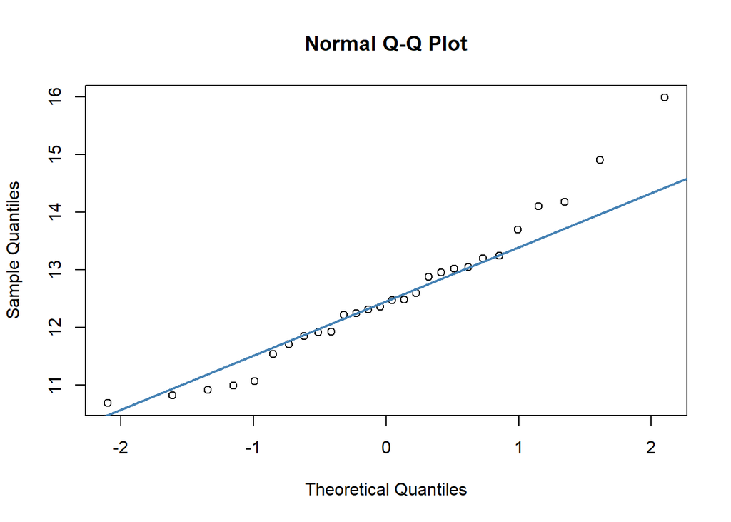

```r
qqnorm(Sur_pos$Posterior)
qqline(Sur_pos$Posterior, col = "steelblue", lwd = 2)
```

```r
shapiro.test(Sur_pos$Posterior)
```

```
##
##  Shapiro-Wilk normality test
##
## data:  Sur_pos$Posterior
## W = 0.95201, p-value = 0.2225
```

```r
shapiro.test(Cenor_pos$Posterior)
```

```
##
##  Shapiro-Wilk normality test
##
## data:  Cenor_pos$Posterior
## W = 0.94734, p-value = 0.2008
```

Dado que el test de hipótesis, normalidad Shapiro-Wilk indican que no hay suficiente evidencia estadística para demostrar que las muestras NO provienen de una distribución normal (p-value > 0.05) y en el QQplot se observa que los datos aproximadamente se alinean a la recta, a pesar de presentar unos outliners en la cola. Por lo que se dice que los datos siguen una distribución normal.

```r
t.test(Cenor_pos$Posterior,Sur_pos$Posterior,paired=FALSE,alternative = "less",mu=1)
```

```
##
##  Welch Two Sample t-test
##
## data:  Cenor_pos$Posterior and Sur_pos$Posterior
## t = -0.58585, df = 50.809, p-value = 0.2803
## alternative hypothesis: true difference in means is less than 1
## 95 percent confidence interval:
##      -Inf 1.334999
## sample estimates:
## mean of x mean of y
##  13.36719  12.54732
```

Dada las diferencias de las medias igual a 0.82 segundos aproximadamente, este se encuentra dentro del intervalo de 95% confianza [-Inf;1.334999], y además el valor p es de 0.2803 para el estadístico de prueba T = -0.58585, considerando 50.809 grados de libertad, es mayor al nivel de significancia (alpha 0.05), por lo que se falla en rechazar la hipótesis nula. Concluimos que la evidencia estadística actual no es suficiente para afirmar que la diferencia entre promedios de las muestras sea menor a 1. Hace falta más evidencia estadística para afirmar que en promedio el tiempo posterior al entrenamiento entre los atletas de la zona Centro-Norte y Sur, el Sur supere al Centro-Norte por menos de 1 segundo.

### 4. ¿Será cierto que hay menos atletas de la zona Centro-Norte que redujeron sus mejores marcas en al menos 3,5 segundos que atletas de la zona Sur que lo hicieron en al menos 1,4 segundos?

Para esta pregunta se tienen dos muestras de datos, atletas de la zona Centro-Norte y atletas de la zona Sur, se arman sus respectivas tablas de datos para trabajar filtrando la tabla de la muestra general de datos.

```r
#Datos atletas de la zona Centro-Norte
data_CN = filter(datos, Zona == "Centro-Norte")

#Datos atletas de la zona Sur
data_S = filter(datos, Zona == "Sur")
```

```r
length(data_CN$Previo)
```

```
## [1] 26
```

```r
length(data_S$Posterior)
```

```
## [1] 28
```

### Hipotesis

Para formular la hipotesis, se debe analizar los datos respecto a la pregunta. Se pregunta por aquellos atletas de cierta zona que cumplan cierta condición (tiempo de reducción de sus mejores marcas), esto puede tener dos posibles resultados, éxito si el tiempo en que redujeron su marca supera el tiempo dado para su zona dentro de la pregunta, o fracaso en caso de que no logren al menos el tiempo dado anteriormente. Por otra parte, se pregunta si es verdadero la afirmación de que hay menos atletas de la zona Centro-Norte que cumplen la condición dada, que atletas de la zona Sur que lo cumplan.

A partir de estos datos elaboramos las hipotesis donde: - $p_{1}$ es la proporción de atletas de la zona Centro-Norte que redujeron sus mejores marcas en al menos 3,5 segundos. - $p_{2}$ es la proporción de atletas de la zona Sur que redujeron sus mejores marcas en al menos 1,4 segundos.

Entonces las hipótesis son:

- $H_{0}$: La proporción de atletas de la zona Centro-Norte que redujeron sus mejores marcas en al menos 3,5 segundos es igual a la proporción de atletas de la zona Sur que lo hicieron en al menos 1,4 segundos.
  $$H_{0}: p_{1}-p_{2}=0$$
- $H_{A}$: La proporción de atletas de la zona Centro-Norte que redujeron sus mejores marcas en al menos 3,5 segundos es menor a la proporción de atletas de la zona Sur que lo hicieron en al menos 1,4 segundos.
  $$H_{A}: p_{1}-p{2}<0$$

### Prueba

Para este problema, se debe estudiar la diferencia entre dos proporciones, que corresponden a las de los atletas de su zona respectiva que cumplieron las condiciones de exito. Para ello, se utilizara el método de Wilson por su mejor cobertura en los niveles de confianza, especialmente en muestras pequeñas, como es el caso actual, con ambas muestras tienen un total de observaciones menores a 30.

### Condiciones

Para utilizar el método de Wilson, se deben cumplir las siguientes condiciones:

1. Las dos muestras son independientes una de la otra
2. Cada proporción por separado sigue el modelo normal, osea, se cumple la condicién de éxito-fracaso, que establece que en las $n$ observaciones se espera observar al menos 10 observaciones correspondientes a éxitos y al menos 10 correspondientes a fracasos(matematicamente: $np \geq 10$ y $n(1 — p) \geq 10$).

Para la primera condición, se puede considerar que ambas muestras son independientes, la zona en que habitan los atletas son distintas, y no se puede decir que haya alguna relación entre ellas.

Para la segunda condiciones, verificamos si se cumple $np \geq 10$ y $n(1-p) \geq 10$ donde $n$ corresponde al número de observaciones, y $p$ la proporción de exito. Para verificar la condición de éxito-fracaso se usa la proporción de éxito muestral $\hat{p}$ como aproximación del parámetro $p$.

```r
#Se calcula la reducción de tiempo que tuvieron los atletas
#Centro-Norte
res_CN = data_CN$Previo - data_CN$Posterior
#Sur
res_S = data_S$Previo - data_S$Posterior

#Se calcula el número de exitos para cada muestra
exito_CN = length(res_CN[res_CN>=3.5])
exito_S = length(res_S[res_S>=1.4])
c(exito_CN,exito_S)
```

```
## [1]  4 17
```

```r
#Se calcula el número de observaciones de cada muestra
obs_CN = length(res_CN)
obs_S = length(res_S)

#Se calcula la proporción de exito para cada muestra
p_CN = exito_CN/obs_CN
p_S = exito_S/obs_S
c(p_CN,p_S)
```

```
## [1] 0.1538462 0.6071429
```

### Resultados

Se aplica el test de Wilson para la muestra para analizar los resultados, con un valor nulo de 0 y alpha 0.05

```r
alpha = 0.05
null_value1 = 0
prop.test(x = c(exito_S,exito_CN), n= c(length(res_CN),length(res_S)) , alternative = "less", conf.level = 1-alpha)
```

```
##
##  2-sample test for equality of proportions with continuity correction
##
## data:  c(exito_S, exito_CN) out of c(length(res_CN), length(res_S))
## X-squared = 12.74, df = 1, p-value = 0.9998
## alternative hypothesis: less
## 95 percent confidence interval:
##  -1.0000000  0.7361825
## sample estimates:
##    prop 1    prop 2
## 0.6538462 0.1428571
```

El valor p dado por el test es mayor al alpha seleccionado, ademas, se tiene un intervalor de confianza de 95% en el intervalo [-1.000,0.7361825] aproximadamente.